# **Problem Statement**

## **Business Context**

Workplace safety in hazardous environments like construction sites and industrial plants is crucial to prevent accidents and injuries. One of the most important safety measures is ensuring workers wear safety helmets, which protect against head injuries from falling objects and machinery. Non-compliance with helmet regulations increases the risk of serious injuries or fatalities, making effective monitoring essential, especially in large-scale operations where manual oversight is prone to errors and inefficiency.

To overcome these challenges, SafeGuard Corp plans to develop an automated image analysis system capable of detecting whether workers are wearing safety helmets. This system will improve safety enforcement, ensuring compliance and reducing the risk of head injuries. By automating helmet monitoring, SafeGuard aims to enhance efficiency, scalability, and accuracy, ultimately fostering a safer work environment while minimizing human error in safety oversight.

## **Objective**

As a data scientist at SafeGuard Corp, you are tasked with developing an image classification model that classifies images into one of two categories:

- **With Helmet:** Workers wearing safety helmets.
- **Without Helmet:** Workers not wearing safety helmets.

## **Data Description**

- **With Helmet:** 311 images showing workers wearing helmets.
- **Without Helmet:** 320 images showing workers not wearing helmets.

**Dataset Characteristics:**

- **Variations in Conditions:** Images include diverse environments such as construction sites, factories, and industrial settings, with variations in lighting, angles, and worker postures to simulate real-world conditions.
- **Worker Activities:** Workers are depicted in different actions such as standing, using tools, or moving, ensuring robust model learning for various scenarios.

# **Installing and Importing the Necessary Libraries**

```python
!pip install tensorflow[and-cuda] scikit-learn==1.6.1 opencv-python==4.12.0.88 seaborn==0.13.2 matplotlib==3.10.0 numpy==2.0.2 pandas==2.2.2 -q
```

[output not shown]

```python
import tensorflow as tf
print("Num GPUs Available:", len(tf.config.list_physical_devices('GPU')))
print(tf.__version__)
```

```
Num GPUs Available: 1
2.19.0
```

**Note:**

- After running the above cell, kindly restart the notebook kernel (for Jupyter Notebook) or runtime (for Google Colab) and run all cells sequentially from the next cell.
- On executing the above line of code, you might see a warning regarding package dependencies. This error message can be ignored as the above code ensures that all necessary libraries and their dependencies are maintained to successfully execute the code in this notebook.

```python
import os
import random
import numpy as np                                                                               # Importing numpy for Matrix Operations
import pandas as pd
import seaborn as sns
import matplotlib.image as mpimg                                                                              # Importing pandas to read CSV files
import matplotlib.pyplot as plt                                                                  # Importting matplotlib for Plotting and visualizing images
import math                                                                                      # Importing math module to perform mathematical operations
import cv2


# Tensorflow modules
import keras
import tensorflow as tf
from tensorflow.keras.preprocessing.image import ImageDataGenerator                              # Importing the ImageDataGenerator for data augmentation
from tensorflow.keras.models import Sequential                                                   # Importing the sequential module to define a sequential model
from tensorflow.keras.layers import Dense,Dropout,Flatten,Conv2D,MaxPooling2D,BatchNormalization # Defining all the layers to build our CNN Model
from tensorflow.keras.optimizers import Adam,SGD                                                 # Importing the optimizers which can be used in our model
from sklearn import preprocessing                                                                # Importing the preprocessing module to preprocess the data
from sklearn.model_selection import train_test_split                                             # Importing train_test_split function to split the data into train and test
from sklearn.metrics import confusion_matrix
from tensorflow.keras.models import Model
from keras.applications.vgg16 import VGG16                                               # Importing confusion_matrix to plot the confusion matrix

# Display images using OpenCV
from google.colab.patches import cv2_imshow

#Imports functions for evaluating the performance of machine learning models
from sklearn.metrics import confusion_matrix, f1_score,accuracy_score, recall_score, precision_score, classification_report
from sklearn.metrics import mean_squared_error as mse                                                 # Importing cv2_imshow from google.patches to display images

# Ignore warnings
import warnings
warnings.filterwarnings('ignore')
```

```python
# Set the seed using keras.utils.set_random_seed. This will set:
# 1) `numpy` seed
# 2) backend random seed
# 3) `python` random seed
tf.keras.utils.set_random_seed(812)
```

# **Data Overview**

## Loading the data

```python
from google.colab import drive
drive.mount('/content/drive')
```

```python
images_proj = np.load('/content/drive/MyDrive/images_proj.npy')
labels_proj = pd.read_csv('/content/drive/MyDrive/Labels_proj.csv')
```

# **Exploratory Data Analysis**

### Plot random images from each of the classes and print their corresponding labels.

```python
def plot_images_random(images,labels):
  num_classes = 2 #two classes are 'with helmet' and 'without helmet'
  categories=np.unique(labels['Label']) #finds all unique labels in my arry. Without helmet = 0, With helmet = 1

  # Define the mapping from numerical label to descriptive class name
  label_name_map = {0: 'Without Helmet', 1: 'With Helmet'}

  rows = 2 # two rows because two classes
  cols = 5 #this can be whatever
  fig_size = plt.figure(figsize=(10,8)) #width and height of my fig size image, 10 width, 8 height
  for i in range (cols):
    for j in range(rows):
      random_image = np.random.randint(0,len(labels)) # Get a random index

      # Get the actual label value (0 or 1) for the random image
      actual_label_value = labels.iloc[random_image]['Label'] #iloc = integer-location

      # Get the descriptive name using the map
      descriptive_label = label_name_map[actual_label_value]#turns 0, 1 to With or Without helmet

      ax = fig_size.add_subplot(rows,cols, i * rows + j + 1) #ax short for axes
      ax.imshow(images[random_image,:])
      ax.set_title(descriptive_label) # Use the descriptive label in the title
      ax.axis('off') # Turn off axis to make plot cleaner
  plt.tight_layout() # Adjust layout to prevent titles from overlapping
  plt.show()
```

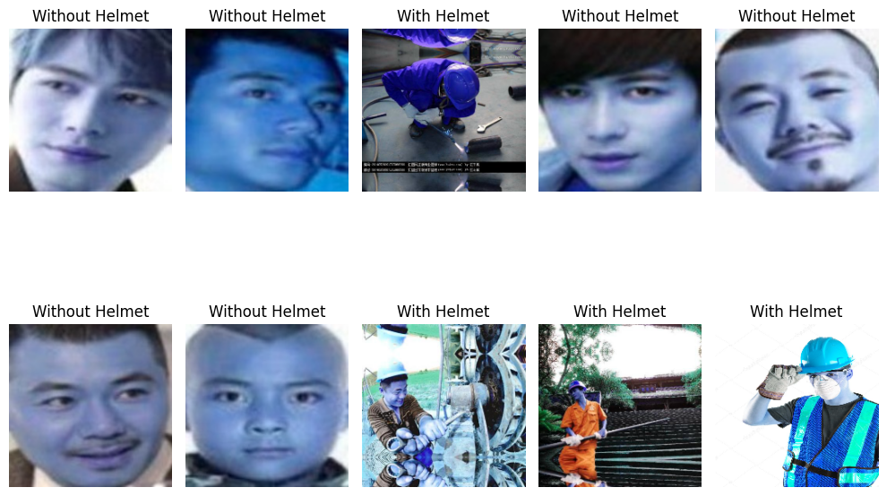

```python
plot_images_random(images_proj,labels_proj)
```

## Checking for class imbalance

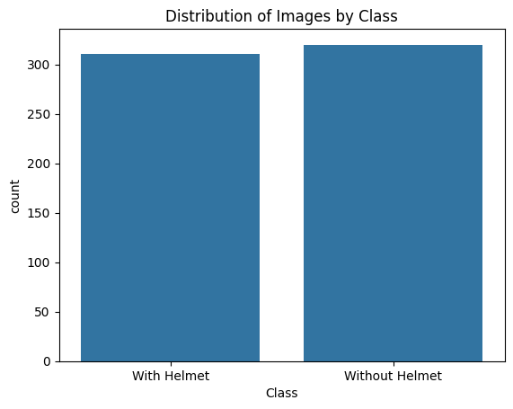

```python
# Define the mapping from numerical label to descriptive class name
label_name_map = {0: 'Without Helmet', 1: 'With Helmet'} #with ones and zeros you must label them.

# Map the numerical labels to descriptive names for plotting
plot_labels = labels_proj['Label'].map(label_name_map)

# Create the countplot with descriptive labels
sns.countplot(x=plot_labels)
plt.xlabel('Class') # Add a clear x-axis label
plt.title('Distribution of Images by Class') # Add a title for clarity
plt.show() # Display the plot
```

# **Data Preprocessing**

## Converting images to grayscale

```python
def convert_to_gray(images):
  #Images_proj is a numpy array, so we create these values to store them
  num_images = images.shape[0]
  height = images.shape[1]
  width = images.shape[2]

  # Create an empty array to store grayscale images
  # Grayscale images have shape (height, width). making sure datatype is the same as images.
  grayscale_images = np.empty((num_images, height, width), dtype=images.dtype)

  for idx in range(num_images):
    grayscale_images[idx] = cv2.cvtColor(images[idx], cv2.COLOR_BGR2GRAY)

  return grayscale_images
```

```python
images_gray = convert_to_gray(images_proj)
```

To verify that `images_gray` is truly grayscale, we can check its shape and the data type and range of its pixel values. Grayscale images should have 2 dimensions (height, width) for a single image, or 3 dimensions (number_of_images, height, width) for a collection. The `dtype` will typically be `uint8` for 0-255 pixel values.

```python
print(f"Shape of images_gray: {images_gray.shape}")# grayscale images are 2 dimensional
print(f"Shape of images_proj: {images_proj.shape}") #rgb have a 3rd dimension
print(f"Data type of images_gray: {images_gray.dtype}") #uint8 is gray datatype.
```

```
Shape of images_gray: (631, 200, 200)
Shape of images_proj: (631, 200, 200, 3)
Data type of images_gray: uint8
```

### Splitting the dataset

```python
#splitting train and temp 80/20, random_state ensures reproducibility
X_train,X_temp,y_train,y_temp = train_test_split(np.array(images_gray),labels_proj,test_size=0.2,random_state=42,stratify=labels_proj)
#splitting test and validation 50/50, stratify keeps labels accurate
X_val,X_test,y_val,y_test = train_test_split(X_temp,y_temp, test_size=0.5,random_state=42,stratify=y_temp)
```

### Data Normalization

```python
X_train_normalized = X_train.astype('float32')/255.0
X_val_normalized = X_val.astype('float32')/25
X_test_normalized = X_test.astype('float32')/255.0
```

# **Model Building**

## Utility Functions

```python
# defining a function to compute different metrics to check performance of a classification model built using statsmodels
def model_performance_classification(model, predictors, target):
    """
    Function to compute different metrics to check classification model performance

    model: classifier
    predictors: independent variables
    target: dependent variable
    """

    # Check if the input needs a channel dimension added (e.g., for grayscale images with 3 dims)
    if predictors.ndim == 3: # If shape is (num_images, height, width)
        predictors_processed = np.expand_dims(predictors, axis=-1) # Make it (num_images, height, width, 1)
    else: # Already 4D (num_images, height, width, channels) or another compatible shape
        predictors_processed = predictors

    # checking which probabilities are greater than threshold
    pred = model.predict(predictors_processed).reshape(-1)>0.5

    target = target.to_numpy().reshape(-1)


    acc = accuracy_score(target, pred)  # to compute Accuracy
    recall = recall_score(target, pred, average='weighted')  # to compute Recall
    precision = precision_score(target, pred, average='weighted')  # to compute Precision
    f1 = f1_score(target, pred, average='weighted')  # to compute F1-score

    # creating a dataframe of metrics
    df_perf = pd.DataFrame({"Accuracy": acc, "Recall": recall, "Precision": precision, "F1 Score": f1,},index=[0],)

    return df_perf
```

```python
def plot_confusion_matrix(model,predictors,target):
    """
    Function to plot the confusion matrix

    model: classifier
    predictors: independent variables
    target: dependent variable
    """

    # Check if the input needs a channel dimension added (e.g., for grayscale images with 3 dims)
    if predictors.ndim == 3: # If shape is (num_images, height, width)
        predictors_processed = np.expand_dims(predictors, axis=-1) # Make it (num_images, height, width, 1)
    else: # Already 4D (num_images, height, width, channels) or another compatible shape
        predictors_processed = predictors

    # checking which probabilities are greater than threshold
    pred = model.predict(predictors_processed).reshape(-1)>0.5

    target = target.to_numpy().reshape(-1)

    # Plotting the Confusion Matrix using confusion matrix() function which is also predefined tensorflow module
    confusion_matrix = tf.math.confusion_matrix(target,pred)
    f, ax = plt.subplots(figsize=(10, 8))
    sns.heatmap(
        confusion_matrix,
        annot=True,
        linewidths=.4,
        fmt="d",
        square=True,
        ax=ax
    )
    plt.show()
```

## Model 1: Simple Convolutional Neural Network (CNN)

```python
#A simple CNN starts with sequential, for simple problems we only need 3-5 layers.
#beginning layers detect simple things. Further in, you want more filters.
#filters should be in powers of two due to success of CNN's with this exponent.
#Conv2D = feature detection Conv2D output = feature maps.
#pooling = summarizer, reduces dimensions, makes NN less reactive to shifts, etc. Reduces compute.
model_1 = Sequential()

# First Convolutional Block
model_1.add(Conv2D(32, (3, 3), activation='relu', input_shape=(200, 200, 1))) # 32 filters, 3x3 kernel, ReLU activation
model_1.add(MaxPooling2D((2, 2))) # 2x2 pooling window

# Second Convolutional Block
#second block takes already learned features, and learns more abstract features to combine them
# second maxpooling takes the feature map and makes an even smaller output.

model_1.add(Conv2D(64, (3, 3), activation='relu')) # 64 filters, 3x3 kernel, ReLU activation
model_1.add(MaxPooling2D((2, 2)))

# Third Convolutional Block
#each block builds on top of each other to produce a clearer, less affected feature map.
model_1.add(Conv2D(128, (3, 3), activation='relu')) # 128 filters, 3x3 kernel, ReLU activation
model_1.add(MaxPooling2D((2, 2)))

# Flatten the output before feeding to Dense layers
#flattens from 3D to 1D.
#dense layers have to be 1D
model_1.add(Flatten())

# Fully Connected Layers (Dense)
#weighted sum, adds bias and sends to activation layer
#weighted sum = all inputs multiplied by a weight, then the sum of the weighted inputs.

model_1.add(Dense(128, activation='relu')) # 128 neurons, ReLU activation
model_1.add(Dropout(0.5)) # Dropout for regularization to prevent overfitting

#1 neuron for binary classifcation, if this was multiple classifications it would be 1 neuron per classification + softmax
model_1.add(Dense(1, activation='sigmoid')) # Output layer with 1 neuron and sigmoid for binary classification

# Compile the model
#if multiple classes, use categorical_crossentropy

model_1.compile(optimizer='adam', loss='binary_crossentropy', metrics=['accuracy'])

# Display model summary
model_1.summary()
```

```
Model: "sequential"
```

```
┏━━━━━━━━━━━━━━━━━━━━━━━━━━━━━━━━━┳━━━━━━━━━━━━━━━━━━━━━━━━┳━━━━━━━━━━━━━━━┓
┃ Layer (type)                    ┃ Output Shape           ┃       Param # ┃
┡━━━━━━━━━━━━━━━━━━━━━━━━━━━━━━━━━╇━━━━━━━━━━━━━━━━━━━━━━━━╇━━━━━━━━━━━━━━━┩
│ conv2d (Conv2D)                 │ (None, 198, 198, 32)   │           320 │
├─────────────────────────────────┼────────────────────────┼───────────────┤
│ max_pooling2d (MaxPooling2D)    │ (None, 99, 99, 32)     │             0 │
├─────────────────────────────────┼────────────────────────┼───────────────┤
│ conv2d_1 (Conv2D)               │ (None, 97, 97, 64)     │        18,496 │
├─────────────────────────────────┼────────────────────────┼───────────────┤
│ max_pooling2d_1 (MaxPooling2D)  │ (None, 48, 48, 64)     │             0 │
├─────────────────────────────────┼────────────────────────┼───────────────┤
│ conv2d_2 (Conv2D)               │ (None, 46, 46, 128)    │        73,856 │
├─────────────────────────────────┼────────────────────────┼───────────────┤
│ max_pooling2d_2 (MaxPooling2D)  │ (None, 23, 23, 128)    │             0 │
├─────────────────────────────────┼────────────────────────┼───────────────┤
│ flatten (Flatten)               │ (None, 67712)          │             0 │
├─────────────────────────────────┼────────────────────────┼───────────────┤
│ dense (Dense)                   │ (None, 128)            │     8,667,264 │
├─────────────────────────────────┼────────────────────────┼───────────────┤
│ dropout (Dropout)               │ (None, 128)            │             0 │
├─────────────────────────────────┼────────────────────────┼───────────────┤
│ dense_1 (Dense)                 │ (None, 1)              │           129 │
└─────────────────────────────────┴────────────────────────┴───────────────┘
```

```
 Total params: 8,760,065 (33.42 MB)
```

```
 Trainable params: 8,760,065 (33.42 MB)
```

```
 Non-trainable params: 0 (0.00 B)
```

```python
# Train the model
history_1 = model_1.fit(
    X_train_normalized, y_train,
    epochs=40, # Number of epochs can be adjusted
    validation_data=(X_val_normalized, y_val),
    batch_size=32 # Batch size can be adjusted
)
```

```
16/16 ━━━━━━━━━━━━━━━━━━━━ 12s 408ms/step - accuracy: 0.5866 - loss: 0.8572 - val_accuracy: 0.9206 - val_loss: 0.5233
16/16 ━━━━━━━━━━━━━━━━━━━━ 1s 47ms/step - accuracy: 0.9565 - loss: 0.2207 - val_accuracy: 0.9841 - val_loss: 0.0193
16/16 ━━━━━━━━━━━━━━━━━━━━ 1s 44ms/step - accuracy: 0.9915 - loss: 0.0534 - val_accuracy: 1.0000 - val_loss: 2.7817e-07
16/16 ━━━━━━━━━━━━━━━━━━━━ 1s 43ms/step - accuracy: 0.9915 - loss: 0.0270 - val_accuracy: 1.0000 - val_loss: 0.0023
16/16 ━━━━━━━━━━━━━━━━━━━━ 1s 42ms/step - accuracy: 0.9896 - loss: 0.0519 - val_accuracy: 0.9841 - val_loss: 0.5537
16/16 ━━━━━━━━━━━━━━━━━━━━ 1s 43ms/step - accuracy: 0.9977 - loss: 0.0199 - val_accuracy: 0.6667 - val_loss: 11.4254
16/16 ━━━━━━━━━━━━━━━━━━━━ 1s 42ms/step - accuracy: 0.9899 - loss: 0.0323 - val_accuracy: 1.0000 - val_loss: 1.0304e-07
16/16 ━━━━━━━━━━━━━━━━━━━━ 1s 42ms/step - accuracy: 1.0000 - loss: 0.0107 - val_accuracy: 0.9841 - val_loss: 0.3904
16/16 ━━━━━━━━━━━━━━━━━━━━ 1s 43ms/step - accuracy: 1.0000 - loss: 0.0052 - val_accuracy: 0.9524 - val_loss: 1.8560
16/16 ━━━━━━━━━━━━━━━━━━━━ 1s 42ms/step - accuracy: 1.0000 - loss: 0.0030 - val_accuracy: 0.9841 - val_loss: 0.3263
16/16 ━━━━━━━━━━━━━━━━━━━━ 1s 42ms/step - accuracy: 1.0000 - loss: 0.0016 - val_accuracy: 0.9683 - val_loss: 1.3190
16/16 ━━━━━━━━━━━━━━━━━━━━ 1s 42ms/step - accuracy: 1.0000 - loss: 0.0018 - val_accuracy: 0.9683 - val_loss: 1.4030
16/16 ━━━━━━━━━━━━━━━━━━━━ 1s 42ms/step - accuracy: 1.0000 - loss: 0.0025 - val_accuracy: 0.9683 - val_loss: 1.2498
16/16 ━━━━━━━━━━━━━━━━━━━━ 1s 43ms/step - accuracy: 1.0000 - loss: 0.0021 - val_accuracy: 0.4921 - val_loss: 129.2173
16/16 ━━━━━━━━━━━━━━━━━━━━ 1s 42ms/step - accuracy: 0.9757 - loss: 0.1408 - val_accuracy: 1.0000 - val_loss: 1.5040e-10
16/16 ━━━━━━━━━━━━━━━━━━━━ 1s 42ms/step - accuracy: 0.9745 - loss: 0.0845 - val_accuracy: 0.9683 - val_loss: 1.1335
16/16 ━━━━━━━━━━━━━━━━━━━━ 1s 46ms/step - accuracy: 0.9989 - loss: 0.0139 - val_accuracy: 0.9524 - val_loss: 1.7399
16/16 ━━━━━━━━━━━━━━━━━━━━ 1s 46ms/step - accuracy: 0.9995 - loss: 0.0047 - val_accuracy: 0.9683 - val_loss: 1.7707
16/16 ━━━━━━━━━━━━━━━━━━━━ 1s 46ms/step - accuracy: 1.0000 - loss: 0.0019 - val_accuracy: 0.4921 - val_loss: 62.8599
16/16 ━━━━━━━━━━━━━━━━━━━━ 1s 45ms/step - accuracy: 0.9992 - loss: 0.0024 - val_accuracy: 0.9841 - val_loss: 0.7456
16/16 ━━━━━━━━━━━━━━━━━━━━ 1s 42ms/step - accuracy: 0.9942 - loss: 0.0157 - val_accuracy: 1.0000 - val_loss: 2.2029e-08
16/16 ━━━━━━━━━━━━━━━━━━━━ 1s 42ms/step - accuracy: 0.9864 - loss: 0.0551 - val_accuracy: 1.0000 - val_loss: 6.3384e-18
16/16 ━━━━━━━━━━━━━━━━━━━━ 1s 43ms/step - accuracy: 0.9902 - loss: 0.0540 - val_accuracy: 0.8730 - val_loss: 5.1335
16/16 ━━━━━━━━━━━━━━━━━━━━ 1s 42ms/step - accuracy: 1.0000 - loss: 0.0099 - val_accuracy: 0.9683 - val_loss: 1.8207
16/16 ━━━━━━━━━━━━━━━━━━━━ 1s 42ms/step - accuracy: 1.0000 - loss: 0.0027 - val_accuracy: 0.9683 - val_loss: 1.1630
16/16 ━━━━━━━━━━━━━━━━━━━━ 1s 42ms/step - accuracy: 1.0000 - loss: 0.0012 - val_accuracy: 0.9683 - val_loss: 2.4230
16/16 ━━━━━━━━━━━━━━━━━━━━ 1s 42ms/step - accuracy: 1.0000 - loss: 0.0037 - val_accuracy: 0.9683 - val_loss: 3.0242
16/16 ━━━━━━━━━━━━━━━━━━━━ 1s 42ms/step - accuracy: 1.0000 - loss: 0.0020 - val_accuracy: 0.9683 - val_loss: 3.0313
16/16 ━━━━━━━━━━━━━━━━━━━━ 1s 42ms/step - accuracy: 1.0000 - loss: 6.8512e-04 - val_accuracy: 0.9683 - val_loss: 2.8513
16/16 ━━━━━━━━━━━━━━━━━━━━ 1s 42ms/step - accuracy: 1.0000 - loss: 0.0035 - val_accuracy: 0.9683 - val_loss: 2.5609
16/16 ━━━━━━━━━━━━━━━━━━━━ 1s 42ms/step - accuracy: 1.0000 - loss: 1.1756e-04 - val_accuracy: 0.9683 - val_loss: 2.2579
16/16 ━━━━━━━━━━━━━━━━━━━━ 1s 42ms/step - accuracy: 1.0000 - loss: 2.4227e-04 - val_accuracy: 0.9683 - val_loss: 2.0409
16/16 ━━━━━━━━━━━━━━━━━━━━ 1s 42ms/step - accuracy: 1.0000 - loss: 0.0016 - val_accuracy: 0.9683 - val_loss: 1.8540
16/16 ━━━━━━━━━━━━━━━━━━━━ 1s 42ms/step - accuracy: 1.0000 - loss: 0.0031 - val_accuracy: 0.9683 - val_loss: 1.7083
16/16 ━━━━━━━━━━━━━━━━━━━━ 1s 45ms/step - accuracy: 1.0000 - loss: 2.2828e-04 - val_accuracy: 0.9683 - val_loss: 2.9798
16/16 ━━━━━━━━━━━━━━━━━━━━ 1s 46ms/step - accuracy: 1.0000 - loss: 3.5202e-04 - val_accuracy: 0.9683 - val_loss: 3.7895
16/16 ━━━━━━━━━━━━━━━━━━━━ 1s 45ms/step - accuracy: 1.0000 - loss: 1.9069e-04 - val_accuracy: 0.9683 - val_loss: 3.6400
16/16 ━━━━━━━━━━━━━━━━━━━━ 1s 48ms/step - accuracy: 1.0000 - loss: 7.0298e-04 - val_accuracy: 0.9683 - val_loss: 3.4795
16/16 ━━━━━━━━━━━━━━━━━━━━ 1s 44ms/step - accuracy: 1.0000 - loss: 3.9357e-05 - val_accuracy: 0.9683 - val_loss: 3.4013
16/16 ━━━━━━━━━━━━━━━━━━━━ 1s 44ms/step - accuracy: 1.0000 - loss: 0.0036 - val_accuracy: 0.9683 - val_loss: 3.2381
```

### Vizualizing the predictions

```
Training Predictions:
16/16 ━━━━━━━━━━━━━━━━━━━━ 2s 82ms/step
```

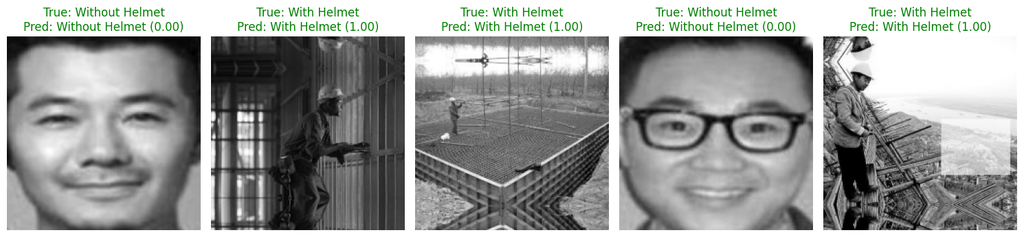

```
Validation Predictions:
2/2 ━━━━━━━━━━━━━━━━━━━━ 0s 290ms/step
```

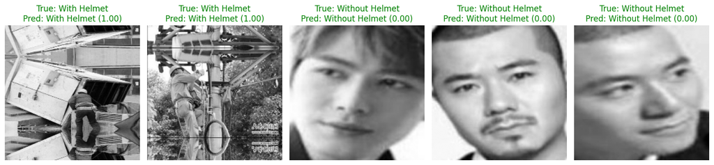

```python
def plot_random_predictions(model, images, true_labels, num_samples=5):
    # Ensure images are in the correct format for prediction (add channel dim)
    if images.ndim == 3:
        images = np.expand_dims(images, axis=-1) # Add a channel dimension for grayscale

    # Get predictions
    predictions = model.predict(images)

    # Select random samples
    indices = np.random.choice(len(images), num_samples, replace=False)

    plt.figure(figsize=(15, 5))
    for i, idx in enumerate(indices):
        plt.subplot(1, num_samples, i + 1)

        # Get original image (remove channel dim for display if added)
        display_image = images[idx].squeeze() # .squeeze() removes single-dimensional entries

        plt.imshow(display_image, cmap='gray')

        true_label_val = true_labels.iloc[idx]['Label']
        predicted_prob = predictions[idx][0]
        predicted_label = 1 if predicted_prob > 0.5 else 0

        true_label_name = 'With Helmet' if true_label_val == 1 else 'Without Helmet'
        predicted_label_name = 'With Helmet' if predicted_label == 1 else 'Without Helmet'

        color = 'green' if true_label_val == predicted_label else 'red'

        plt.title(f"True: {true_label_name}\nPred: {predicted_label_name} ({predicted_prob:.2f})", color=color)
        plt.axis('off')
    plt.tight_layout()
    plt.show()

print('Training Predictions:')
plot_random_predictions(model_1, X_train_normalized, y_train, num_samples=5)

print('Validation Predictions:')
plot_random_predictions(model_1, X_val_normalized, y_val, num_samples=5)
```

```python
plot_confusion_matrix(model_1, X_train_normalized, y_train)
m1_train = model_performance_classification(model_1, X_train_normalized, y_train)
m1_val = model_performance_classification(model_1, X_val_normalized, y_val)
```

[output not shown]

```
16/16 ━━━━━━━━━━━━━━━━━━━━ 0s 14ms/step
```

```
16/16 ━━━━━━━━━━━━━━━━━━━━ 0s 11ms/step
2/2 ━━━━━━━━━━━━━━━━━━━━ 0s 26ms/step
```

## Model 2: (VGG-16 (Base))

```python
#initialize the vgg model
 #vgg works in RGB so I should use the normal images_proj
vgg_model = VGG16(weights='imagenet', include_top=False, input_shape=(200,200,3))
vgg_model.summary()
```

```
Downloading data from https://storage.googleapis.com/tensorflow/keras-applications/vgg16/vgg16_weights_tf_dim_ordering_tf_kernels_notop.h5
58889256/58889256 ━━━━━━━━━━━━━━━━━━━━ 0s 0us/step
```

```
Model: "vgg16"
```

```
┏━━━━━━━━━━━━━━━━━━━━━━━━━━━━━━━━━┳━━━━━━━━━━━━━━━━━━━━━━━━┳━━━━━━━━━━━━━━━┓
┃ Layer (type)                    ┃ Output Shape           ┃       Param # ┃
┡━━━━━━━━━━━━━━━━━━━━━━━━━━━━━━━━━╇━━━━━━━━━━━━━━━━━━━━━━━━╇━━━━━━━━━━━━━━━┩
│ input_layer_1 (InputLayer)      │ (None, 200, 200, 3)    │             0 │
├─────────────────────────────────┼────────────────────────┼───────────────┤
│ block1_conv1 (Conv2D)           │ (None, 200, 200, 64)   │         1,792 │
├─────────────────────────────────┼────────────────────────┼───────────────┤
│ block1_conv2 (Conv2D)           │ (None, 200, 200, 64)   │        36,928 │
├─────────────────────────────────┼────────────────────────┼───────────────┤
│ block1_pool (MaxPooling2D)      │ (None, 100, 100, 64)   │             0 │
├─────────────────────────────────┼────────────────────────┼───────────────┤
│ block2_conv1 (Conv2D)           │ (None, 100, 100, 128)  │        73,856 │
├─────────────────────────────────┼────────────────────────┼───────────────┤
│ block2_conv2 (Conv2D)           │ (None, 100, 100, 128)  │       147,584 │
├─────────────────────────────────┼────────────────────────┼───────────────┤
│ block2_pool (MaxPooling2D)      │ (None, 50, 50, 128)    │             0 │
├─────────────────────────────────┼────────────────────────┼───────────────┤
│ block3_conv1 (Conv2D)           │ (None, 50, 50, 256)    │       295,168 │
├─────────────────────────────────┼────────────────────────┼───────────────┤
│ block3_conv2 (Conv2D)           │ (None, 50, 50, 256)    │       590,080 │
├─────────────────────────────────┼────────────────────────┼───────────────┤
│ block3_conv3 (Conv2D)           │ (None, 50, 50, 256)    │       590,080 │
├─────────────────────────────────┼────────────────────────┼───────────────┤
│ block3_pool (MaxPooling2D)      │ (None, 25, 25, 256)    │             0 │
├─────────────────────────────────┼────────────────────────┼───────────────┤
│ block4_conv1 (Conv2D)           │ (None, 25, 25, 512)    │     1,180,160 │
├─────────────────────────────────┼────────────────────────┼───────────────┤
│ block4_conv2 (Conv2D)           │ (None, 25, 25, 512)    │     2,359,808 │
├─────────────────────────────────┼────────────────────────┼───────────────┤
│ block4_conv3 (Conv2D)           │ (None, 25, 25, 512)    │     2,359,808 │
├─────────────────────────────────┼────────────────────────┼───────────────┤
│ block4_pool (MaxPooling2D)      │ (None, 12, 12, 512)    │             0 │
├─────────────────────────────────┼────────────────────────┼───────────────┤
│ block5_conv1 (Conv2D)           │ (None, 12, 12, 512)    │     2,359,808 │
├─────────────────────────────────┼────────────────────────┼───────────────┤
│ block5_conv2 (Conv2D)           │ (None, 12, 12, 512)    │     2,359,808 │
├─────────────────────────────────┼────────────────────────┼───────────────┤
│ block5_conv3 (Conv2D)           │ (None, 12, 12, 512)    │     2,359,808 │
├─────────────────────────────────┼────────────────────────┼───────────────┤
│ block5_pool (MaxPooling2D)      │ (None, 6, 6, 512)      │             0 │
└─────────────────────────────────┴────────────────────────┴───────────────┘
```

```
 Total params: 14,714,688 (56.13 MB)
```

```
 Trainable params: 14,714,688 (56.13 MB)
```

```
 Non-trainable params: 0 (0.00 B)
```

```python
#images_proj dataset
#VGG models use RGB
#splitting train and temp 80/20, random_state ensures reproducibility
X_trainRGB,X_tempRGB,y_trainRGB,y_tempRGB = train_test_split(np.array(images_proj),labels_proj,test_size=0.2,random_state=42,stratify=labels_proj)
#splitting test and validation 50/50, stratify keeps labels accurate
X_valRGB,X_testRGB,y_valRGB,y_testRGB = train_test_split(X_tempRGB,y_tempRGB, test_size=0.5,random_state=42,stratify=y_tempRGB)
```

```python
X_train_normalizedRGB = X_trainRGB.astype('float32')/255.0
X_val_normalizedRGB = X_valRGB.astype('float32')/25
X_test_normalizedRGB = X_testRGB.astype('float32')/255.0
```

```python
#make layers non trainable
for layer in vgg_model.layers:
  layer.trainable = False
```

```python
input_tensor = tf.keras.Input(shape=(200, 200, 3), name='input_image')
x = vgg_model(input_tensor, training=False) # Pass input_tensor through pre-trained VGG model
x = Flatten()(x) # Flatten the output of VGG16
output_tensor = Dense(1, activation='sigmoid')(x) # Add a Dense output layer for binary classification

model_2 = tf.keras.Model(inputs=input_tensor, outputs=output_tensor)

# Compile the model
model_2.compile(optimizer='adam', loss='binary_crossentropy', metrics=['accuracy'])

# Display model summary
model_2.summary()
```

```
Model: "functional_10"
```

```
┏━━━━━━━━━━━━━━━━━━━━━━━━━━━━━━━━━┳━━━━━━━━━━━━━━━━━━━━━━━━┳━━━━━━━━━━━━━━━┓
┃ Layer (type)                    ┃ Output Shape           ┃       Param # ┃
┡━━━━━━━━━━━━━━━━━━━━━━━━━━━━━━━━━╇━━━━━━━━━━━━━━━━━━━━━━━━╇━━━━━━━━━━━━━━━┩
│ input_image (InputLayer)        │ (None, 200, 200, 3)    │             0 │
├─────────────────────────────────┼────────────────────────┼───────────────┤
│ vgg16 (Functional)              │ (None, 6, 6, 512)      │    14,714,688 │
├─────────────────────────────────┼────────────────────────┼───────────────┤
│ flatten_1 (Flatten)             │ (None, 18432)          │             0 │
├─────────────────────────────────┼────────────────────────┼───────────────┤
│ dense_2 (Dense)                 │ (None, 1)              │        18,433 │
└─────────────────────────────────┴────────────────────────┴───────────────┘
```

```
 Total params: 14,733,121 (56.20 MB)
```

```
 Trainable params: 18,433 (72.00 KB)
```

```
 Non-trainable params: 14,714,688 (56.13 MB)
```

```python
#Train model
History_2 = model_2.fit(X_train_normalizedRGB, y_trainRGB, epochs=40, validation_data=(X_val_normalizedRGB, y_valRGB),
batch_size = 32)
```

```
16/16 ━━━━━━━━━━━━━━━━━━━━ 31s 1s/step - accuracy: 0.8157 - loss: 0.3678 - val_accuracy: 1.0000 - val_loss: 0.0191
16/16 ━━━━━━━━━━━━━━━━━━━━ 3s 180ms/step - accuracy: 1.0000 - loss: 0.0085 - val_accuracy: 1.0000 - val_loss: 0.0030
16/16 ━━━━━━━━━━━━━━━━━━━━ 3s 179ms/step - accuracy: 1.0000 - loss: 0.0037 - val_accuracy: 1.0000 - val_loss: 0.0016
16/16 ━━━━━━━━━━━━━━━━━━━━ 3s 181ms/step - accuracy: 1.0000 - loss: 0.0028 - val_accuracy: 1.0000 - val_loss: 0.0016
16/16 ━━━━━━━━━━━━━━━━━━━━ 3s 185ms/step - accuracy: 1.0000 - loss: 0.0021 - val_accuracy: 1.0000 - val_loss: 0.0014
16/16 ━━━━━━━━━━━━━━━━━━━━ 3s 184ms/step - accuracy: 1.0000 - loss: 0.0018 - val_accuracy: 1.0000 - val_loss: 0.0012
16/16 ━━━━━━━━━━━━━━━━━━━━ 3s 185ms/step - accuracy: 1.0000 - loss: 0.0016 - val_accuracy: 1.0000 - val_loss: 0.0010
16/16 ━━━━━━━━━━━━━━━━━━━━ 3s 186ms/step - accuracy: 1.0000 - loss: 0.0015 - val_accuracy: 1.0000 - val_loss: 9.1336e-04
16/16 ━━━━━━━━━━━━━━━━━━━━ 3s 188ms/step - accuracy: 1.0000 - loss: 0.0013 - val_accuracy: 1.0000 - val_loss: 8.2380e-04
16/16 ━━━━━━━━━━━━━━━━━━━━ 3s 190ms/step - accuracy: 1.0000 - loss: 0.0012 - val_accuracy: 1.0000 - val_loss: 7.4523e-04
16/16 ━━━━━━━━━━━━━━━━━━━━ 3s 189ms/step - accuracy: 1.0000 - loss: 0.0011 - val_accuracy: 1.0000 - val_loss: 6.7844e-04
16/16 ━━━━━━━━━━━━━━━━━━━━ 3s 191ms/step - accuracy: 1.0000 - loss: 0.0010 - val_accuracy: 1.0000 - val_loss: 6.2156e-04
16/16 ━━━━━━━━━━━━━━━━━━━━ 3s 192ms/step - accuracy: 1.0000 - loss: 9.2485e-04 - val_accuracy: 1.0000 - val_loss: 5.7234e-04
16/16 ━━━━━━━━━━━━━━━━━━━━ 3s 199ms/step - accuracy: 1.0000 - loss: 8.5360e-04 - val_accuracy: 1.0000 - val_loss: 5.2927e-04
16/16 ━━━━━━━━━━━━━━━━━━━━ 3s 194ms/step - accuracy: 1.0000 - loss: 7.9062e-04 - val_accuracy: 1.0000 - val_loss: 4.9133e-04
16/16 ━━━━━━━━━━━━━━━━━━━━ 3s 196ms/step - accuracy: 1.0000 - loss: 7.3468e-04 - val_accuracy: 1.0000 - val_loss: 4.5774e-04
16/16 ━━━━━━━━━━━━━━━━━━━━ 3s 196ms/step - accuracy: 1.0000 - loss: 6.8473e-04 - val_accuracy: 1.0000 - val_loss: 4.2783e-04
16/16 ━━━━━━━━━━━━━━━━━━━━ 3s 196ms/step - accuracy: 1.0000 - loss: 6.3993e-04 - val_accuracy: 1.0000 - val_loss: 4.0105e-04
16/16 ━━━━━━━━━━━━━━━━━━━━ 3s 192ms/step - accuracy: 1.0000 - loss: 5.9960e-04 - val_accuracy: 1.0000 - val_loss: 3.7696e-04
16/16 ━━━━━━━━━━━━━━━━━━━━ 3s 189ms/step - accuracy: 1.0000 - loss: 5.6316e-04 - val_accuracy: 1.0000 - val_loss: 3.5520e-04
16/16 ━━━━━━━━━━━━━━━━━━━━ 3s 189ms/step - accuracy: 1.0000 - loss: 5.3010e-04 - val_accuracy: 1.0000 - val_loss: 3.3547e-04
16/16 ━━━━━━━━━━━━━━━━━━━━ 3s 190ms/step - accuracy: 1.0000 - loss: 5.0001e-04 - val_accuracy: 1.0000 - val_loss: 3.1750e-04
16/16 ━━━━━━━━━━━━━━━━━━━━ 3s 189ms/step - accuracy: 1.0000 - loss: 4.7254e-04 - val_accuracy: 1.0000 - val_loss: 3.0108e-04
16/16 ━━━━━━━━━━━━━━━━━━━━ 3s 184ms/step - accuracy: 1.0000 - loss: 4.4739e-04 - val_accuracy: 1.0000 - val_loss: 2.8604e-04
16/16 ━━━━━━━━━━━━━━━━━━━━ 3s 185ms/step - accuracy: 1.0000 - loss: 4.2430e-04 - val_accuracy: 1.0000 - val_loss: 2.7221e-04
16/16 ━━━━━━━━━━━━━━━━━━━━ 3s 186ms/step - accuracy: 1.0000 - loss: 4.0304e-04 - val_accuracy: 1.0000 - val_loss: 2.5946e-04
16/16 ━━━━━━━━━━━━━━━━━━━━ 3s 188ms/step - accuracy: 1.0000 - loss: 3.8342e-04 - val_accuracy: 1.0000 - val_loss: 2.4767e-04
16/16 ━━━━━━━━━━━━━━━━━━━━ 3s 185ms/step - accuracy: 1.0000 - loss: 3.6527e-04 - val_accuracy: 1.0000 - val_loss: 2.3675e-04
16/16 ━━━━━━━━━━━━━━━━━━━━ 3s 186ms/step - accuracy: 1.0000 - loss: 3.4844e-04 - val_accuracy: 1.0000 - val_loss: 2.2661e-04
16/16 ━━━━━━━━━━━━━━━━━━━━ 3s 186ms/step - accuracy: 1.0000 - loss: 3.3281e-04 - val_accuracy: 1.0000 - val_loss: 2.1718e-04
16/16 ━━━━━━━━━━━━━━━━━━━━ 3s 188ms/step - accuracy: 1.0000 - loss: 3.1826e-04 - val_accuracy: 1.0000 - val_loss: 2.0837e-04
16/16 ━━━━━━━━━━━━━━━━━━━━ 3s 186ms/step - accuracy: 1.0000 - loss: 3.0468e-04 - val_accuracy: 1.0000 - val_loss: 2.0015e-04
16/16 ━━━━━━━━━━━━━━━━━━━━ 3s 186ms/step - accuracy: 1.0000 - loss: 2.9200e-04 - val_accuracy: 1.0000 - val_loss: 1.9245e-04
16/16 ━━━━━━━━━━━━━━━━━━━━ 3s 186ms/step - accuracy: 1.0000 - loss: 2.8013e-04 - val_accuracy: 1.0000 - val_loss: 1.8523e-04
16/16 ━━━━━━━━━━━━━━━━━━━━ 3s 189ms/step - accuracy: 1.0000 - loss: 2.6900e-04 - val_accuracy: 1.0000 - val_loss: 1.7844e-04
16/16 ━━━━━━━━━━━━━━━━━━━━ 3s 190ms/step - accuracy: 1.0000 - loss: 2.5855e-04 - val_accuracy: 1.0000 - val_loss: 1.7206e-04
16/16 ━━━━━━━━━━━━━━━━━━━━ 3s 187ms/step - accuracy: 1.0000 - loss: 2.4873e-04 - val_accuracy: 1.0000 - val_loss: 1.6605e-04
16/16 ━━━━━━━━━━━━━━━━━━━━ 3s 188ms/step - accuracy: 1.0000 - loss: 2.3948e-04 - val_accuracy: 1.0000 - val_loss: 1.6037e-04
16/16 ━━━━━━━━━━━━━━━━━━━━ 3s 188ms/step - accuracy: 1.0000 - loss: 2.3076e-04 - val_accuracy: 1.0000 - val_loss: 1.5501e-04
16/16 ━━━━━━━━━━━━━━━━━━━━ 3s 194ms/step - accuracy: 1.0000 - loss: 2.2252e-04 - val_accuracy: 1.0000 - val_loss: 1.4993e-04
```

### Visualizing the prediction:

```python
plot_confusion_matrix(model_2, X_train_normalizedRGB, y_trainRGB)
m2_train = model_performance_classification(model_2, X_train_normalizedRGB, y_trainRGB)
```

[output not shown]

```
16/16 ━━━━━━━━━━━━━━━━━━━━ 4s 227ms/step
```

```
16/16 ━━━━━━━━━━━━━━━━━━━━ 3s 159ms/step
```

```python
plot_confusion_matrix(model_2, X_val_normalizedRGB, y_valRGB)
m2_val = model_performance_classification(model_2, X_val_normalizedRGB, y_valRGB)
```

[output not shown]

```
2/2 ━━━━━━━━━━━━━━━━━━━━ 2s 1s/step
```

```
2/2 ━━━━━━━━━━━━━━━━━━━━ 0s 193ms/step
```

## Model 3: (VGG-16 (Base + FFNN))

```python
input_tensor = tf.keras.Input(shape=(200, 200, 3), name='input_image')
x = vgg_model(input_tensor, training=False)
x = Flatten()(x)
x = Dense(128, activation='relu')(x)
x = Dropout(0.2)(x)
x = Dense(64, activation='relu')(x)
output_tensor = Dense(1, activation='sigmoid')(x)

model_3 = tf.keras.Model(inputs=input_tensor, outputs=output_tensor)

# Compile the model
model_3.compile(optimizer='adam', loss='binary_crossentropy', metrics=['accuracy'])

# Display model summary
model_3.summary()
```

```
Model: "functional_14"
```

```
┏━━━━━━━━━━━━━━━━━━━━━━━━━━━━━━━━━┳━━━━━━━━━━━━━━━━━━━━━━━━┳━━━━━━━━━━━━━━━┓
┃ Layer (type)                    ┃ Output Shape           ┃       Param # ┃
┡━━━━━━━━━━━━━━━━━━━━━━━━━━━━━━━━━╇━━━━━━━━━━━━━━━━━━━━━━━━╇━━━━━━━━━━━━━━━┩
│ input_image (InputLayer)        │ (None, 200, 200, 3)    │             0 │
├─────────────────────────────────┼────────────────────────┼───────────────┤
│ vgg16 (Functional)              │ (None, 6, 6, 512)      │    14,714,688 │
├─────────────────────────────────┼────────────────────────┼───────────────┤
│ flatten_5 (Flatten)             │ (None, 18432)          │             0 │
├─────────────────────────────────┼────────────────────────┼───────────────┤
│ dense_12 (Dense)                │ (None, 128)            │     2,359,424 │
├─────────────────────────────────┼────────────────────────┼───────────────┤
│ dropout_4 (Dropout)             │ (None, 128)            │             0 │
├─────────────────────────────────┼────────────────────────┼───────────────┤
│ dense_13 (Dense)                │ (None, 64)             │         8,256 │
├─────────────────────────────────┼────────────────────────┼───────────────┤
│ dense_14 (Dense)                │ (None, 1)              │            65 │
└─────────────────────────────────┴────────────────────────┴───────────────┘
```

```
 Total params: 17,082,433 (65.16 MB)
```

```
 Trainable params: 2,367,745 (9.03 MB)
```

```
 Non-trainable params: 14,714,688 (56.13 MB)
```

```python
#Train model
History_3 = model_3.fit(X_train_normalizedRGB, y_trainRGB, epochs=40, validation_data=(X_val_normalizedRGB, y_valRGB),
batch_size = 32)
```

```
16/16 ━━━━━━━━━━━━━━━━━━━━ 10s 439ms/step - accuracy: 0.8316 - loss: 0.5870 - val_accuracy: 1.0000 - val_loss: 1.6573e-04
16/16 ━━━━━━━━━━━━━━━━━━━━ 3s 185ms/step - accuracy: 0.9937 - loss: 0.0089 - val_accuracy: 1.0000 - val_loss: 1.9224e-05
16/16 ━━━━━━━━━━━━━━━━━━━━ 3s 187ms/step - accuracy: 1.0000 - loss: 1.9101e-04 - val_accuracy: 1.0000 - val_loss: 6.1138e-06
16/16 ━━━━━━━━━━━━━━━━━━━━ 3s 187ms/step - accuracy: 1.0000 - loss: 2.0083e-04 - val_accuracy: 1.0000 - val_loss: 4.0545e-06
16/16 ━━━━━━━━━━━━━━━━━━━━ 3s 195ms/step - accuracy: 1.0000 - loss: 0.0019 - val_accuracy: 1.0000 - val_loss: 5.5404e-06
16/16 ━━━━━━━━━━━━━━━━━━━━ 3s 193ms/step - accuracy: 1.0000 - loss: 2.3188e-04 - val_accuracy: 1.0000 - val_loss: 3.9546e-06
16/16 ━━━━━━━━━━━━━━━━━━━━ 3s 195ms/step - accuracy: 1.0000 - loss: 1.1730e-04 - val_accuracy: 1.0000 - val_loss: 2.8161e-06
16/16 ━━━━━━━━━━━━━━━━━━━━ 3s 195ms/step - accuracy: 1.0000 - loss: 9.6042e-05 - val_accuracy: 1.0000 - val_loss: 2.2101e-06
16/16 ━━━━━━━━━━━━━━━━━━━━ 3s 200ms/step - accuracy: 1.0000 - loss: 5.5850e-05 - val_accuracy: 1.0000 - val_loss: 2.1864e-06
16/16 ━━━━━━━━━━━━━━━━━━━━ 3s 199ms/step - accuracy: 1.0000 - loss: 5.9045e-05 - val_accuracy: 1.0000 - val_loss: 2.5071e-06
16/16 ━━━━━━━━━━━━━━━━━━━━ 3s 201ms/step - accuracy: 1.0000 - loss: 2.5177e-04 - val_accuracy: 1.0000 - val_loss: 2.3584e-06
16/16 ━━━━━━━━━━━━━━━━━━━━ 3s 196ms/step - accuracy: 1.0000 - loss: 4.6735e-05 - val_accuracy: 1.0000 - val_loss: 2.2733e-06
16/16 ━━━━━━━━━━━━━━━━━━━━ 3s 196ms/step - accuracy: 1.0000 - loss: 3.3647e-05 - val_accuracy: 1.0000 - val_loss: 2.2541e-06
16/16 ━━━━━━━━━━━━━━━━━━━━ 3s 191ms/step - accuracy: 1.0000 - loss: 3.5041e-05 - val_accuracy: 1.0000 - val_loss: 2.2989e-06
16/16 ━━━━━━━━━━━━━━━━━━━━ 3s 188ms/step - accuracy: 1.0000 - loss: 4.7237e-05 - val_accuracy: 1.0000 - val_loss: 2.2751e-06
16/16 ━━━━━━━━━━━━━━━━━━━━ 3s 187ms/step - accuracy: 1.0000 - loss: 4.3162e-05 - val_accuracy: 1.0000 - val_loss: 2.1989e-06
16/16 ━━━━━━━━━━━━━━━━━━━━ 3s 188ms/step - accuracy: 1.0000 - loss: 2.2603e-05 - val_accuracy: 1.0000 - val_loss: 2.1602e-06
16/16 ━━━━━━━━━━━━━━━━━━━━ 3s 188ms/step - accuracy: 1.0000 - loss: 2.8941e-05 - val_accuracy: 1.0000 - val_loss: 2.1771e-06
16/16 ━━━━━━━━━━━━━━━━━━━━ 3s 186ms/step - accuracy: 1.0000 - loss: 7.4182e-05 - val_accuracy: 1.0000 - val_loss: 1.7575e-06
16/16 ━━━━━━━━━━━━━━━━━━━━ 3s 186ms/step - accuracy: 1.0000 - loss: 3.0291e-05 - val_accuracy: 1.0000 - val_loss: 1.3077e-06
16/16 ━━━━━━━━━━━━━━━━━━━━ 3s 185ms/step - accuracy: 1.0000 - loss: 3.6339e-05 - val_accuracy: 1.0000 - val_loss: 1.1984e-06
16/16 ━━━━━━━━━━━━━━━━━━━━ 3s 188ms/step - accuracy: 1.0000 - loss: 3.8805e-05 - val_accuracy: 1.0000 - val_loss: 1.2494e-06
16/16 ━━━━━━━━━━━━━━━━━━━━ 3s 185ms/step - accuracy: 1.0000 - loss: 2.8975e-05 - val_accuracy: 1.0000 - val_loss: 1.2532e-06
16/16 ━━━━━━━━━━━━━━━━━━━━ 3s 185ms/step - accuracy: 1.0000 - loss: 1.5942e-05 - val_accuracy: 1.0000 - val_loss: 1.2305e-06
16/16 ━━━━━━━━━━━━━━━━━━━━ 3s 186ms/step - accuracy: 1.0000 - loss: 2.9472e-05 - val_accuracy: 1.0000 - val_loss: 1.0844e-06
16/16 ━━━━━━━━━━━━━━━━━━━━ 3s 188ms/step - accuracy: 1.0000 - loss: 3.1844e-05 - val_accuracy: 1.0000 - val_loss: 1.0465e-06
16/16 ━━━━━━━━━━━━━━━━━━━━ 3s 187ms/step - accuracy: 1.0000 - loss: 2.2287e-05 - val_accuracy: 1.0000 - val_loss: 1.0656e-06
16/16 ━━━━━━━━━━━━━━━━━━━━ 3s 185ms/step - accuracy: 1.0000 - loss: 3.6181e-05 - val_accuracy: 1.0000 - val_loss: 9.9730e-07
16/16 ━━━━━━━━━━━━━━━━━━━━ 3s 186ms/step - accuracy: 1.0000 - loss: 2.0944e-05 - val_accuracy: 1.0000 - val_loss: 8.5037e-07
16/16 ━━━━━━━━━━━━━━━━━━━━ 3s 186ms/step - accuracy: 1.0000 - loss: 5.7982e-04 - val_accuracy: 1.0000 - val_loss: 1.2626e-06
16/16 ━━━━━━━━━━━━━━━━━━━━ 3s 192ms/step - accuracy: 1.0000 - loss: 1.3165e-05 - val_accuracy: 1.0000 - val_loss: 1.2891e-06
16/16 ━━━━━━━━━━━━━━━━━━━━ 3s 187ms/step - accuracy: 1.0000 - loss: 4.9968e-05 - val_accuracy: 1.0000 - val_loss: 1.0969e-06
16/16 ━━━━━━━━━━━━━━━━━━━━ 3s 188ms/step - accuracy: 1.0000 - loss: 1.7561e-05 - val_accuracy: 1.0000 - val_loss: 9.1340e-07
16/16 ━━━━━━━━━━━━━━━━━━━━ 3s 189ms/step - accuracy: 1.0000 - loss: 2.2428e-05 - val_accuracy: 1.0000 - val_loss: 8.1055e-07
16/16 ━━━━━━━━━━━━━━━━━━━━ 3s 193ms/step - accuracy: 1.0000 - loss: 1.1275e-05 - val_accuracy: 1.0000 - val_loss: 7.4409e-07
16/16 ━━━━━━━━━━━━━━━━━━━━ 3s 192ms/step - accuracy: 1.0000 - loss: 2.6139e-05 - val_accuracy: 1.0000 - val_loss: 7.0613e-07
16/16 ━━━━━━━━━━━━━━━━━━━━ 3s 191ms/step - accuracy: 1.0000 - loss: 1.1511e-05 - val_accuracy: 1.0000 - val_loss: 6.5595e-07
16/16 ━━━━━━━━━━━━━━━━━━━━ 3s 191ms/step - accuracy: 1.0000 - loss: 1.4350e-05 - val_accuracy: 1.0000 - val_loss: 6.3457e-07
16/16 ━━━━━━━━━━━━━━━━━━━━ 3s 194ms/step - accuracy: 1.0000 - loss: 1.2889e-05 - val_accuracy: 1.0000 - val_loss: 6.3136e-07
16/16 ━━━━━━━━━━━━━━━━━━━━ 3s 193ms/step - accuracy: 1.0000 - loss: 4.8010e-05 - val_accuracy: 1.0000 - val_loss: 6.7040e-07
```

#### Visualizing the predictions

```
2/2 ━━━━━━━━━━━━━━━━━━━━ 1s 186ms/step
```

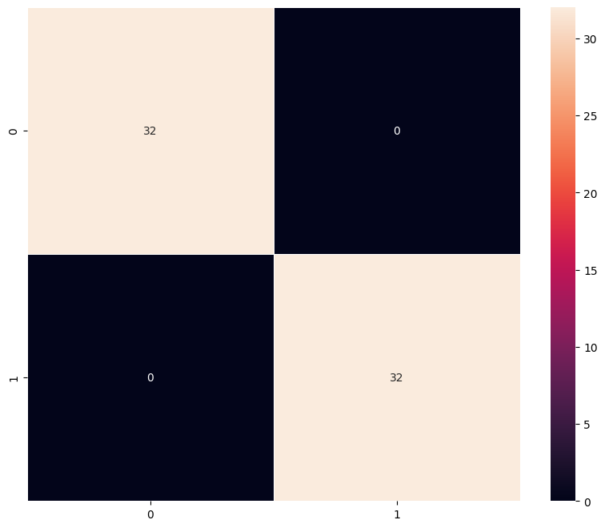

```
2/2 ━━━━━━━━━━━━━━━━━━━━ 0s 187ms/step
```

```python
plot_confusion_matrix(model_3, X_test_normalizedRGB, y_testRGB)
m3_train = model_performance_classification(model_3, X_test_normalizedRGB, y_testRGB)
```

```python
plot_confusion_matrix(model_3, X_val_normalizedRGB, y_valRGB)
m3_val = model_performance_classification(model_3, X_val_normalizedRGB, y_valRGB)
```

[output not shown]

```
2/2 ━━━━━━━━━━━━━━━━━━━━ 2s 1s/step
```

```
2/2 ━━━━━━━━━━━━━━━━━━━━ 0s 183ms/step
```

## Model 4: (VGG-16 (Base + FFNN + Data Augmentation)

## Train Model 4 with Data Augmentation

- In most of the real-world case studies, it is challenging to acquire a large number of images and then train CNNs.
- To overcome this problem, one approach we might consider is **Data Augmentation**.
- CNNs have the property of **translational invariance**, which means they can recognise an object even if its appearance shifts translationally in some way. - Taking this attribute into account, we can augment the images using the techniques listed below
  - Horizontal Flip (should be set to True/False)
  - Vertical Flip (should be set to True/False)
  - Height Shift (should be between 0 and 1)
  - Width Shift (should be between 0 and 1)
  - Rotation (should be between 0 and 180)
  - Shear (should be between 0 and 1)
  - Zoom (should be between 0 and 1) etc.

Remember, **data augmentation should not be used in the validation/test data set**.

```python
train_datagen = ImageDataGenerator(
    rotation_range=45, # Slightly increased rotation
    width_shift_range=0.2, # More moderate shift
    height_shift_range=0.2, # More moderate shift
    shear_range=0.2, # More moderate shear
    zoom_range=0.2, # More moderate zoom
    horizontal_flip=True
)

val_datagen = ImageDataGenerator() # No augmentation for validation data

print("ImageDataGenerator for training data (with augmentation) and validation data (without augmentation) have been instantiated.")
```

```
ImageDataGenerator for training data (with augmentation) and validation data (without augmentation) have been instantiated.
```

```python
input_tensor_4 = tf.keras.Input(shape=(200, 200, 3), name='input_image_model4')
x = vgg_model(input_tensor_4, training=False) # Use the pre-trained VGG model with frozen layers
x = Flatten()(x)
x = Dense(128, activation='relu')(x)
x = Dropout(0.2)(x)
x = Dense(64, activation='relu')(x)
output_tensor_4 = Dense(1, activation='sigmoid')(x)

model_4 = tf.keras.Model(inputs=input_tensor_4, outputs=output_tensor_4)

# Compile Model 4
model_4.compile(optimizer='adam', loss='binary_crossentropy', metrics=['accuracy'])

# Display model summary
model_4.summary()
```

```
Model: "functional_15"
```

```
┏━━━━━━━━━━━━━━━━━━━━━━━━━━━━━━━━━┳━━━━━━━━━━━━━━━━━━━━━━━━┳━━━━━━━━━━━━━━━┓
┃ Layer (type)                    ┃ Output Shape           ┃       Param # ┃
┡━━━━━━━━━━━━━━━━━━━━━━━━━━━━━━━━━╇━━━━━━━━━━━━━━━━━━━━━━━━╇━━━━━━━━━━━━━━━┩
│ input_image_model4 (InputLayer) │ (None, 200, 200, 3)    │             0 │
├─────────────────────────────────┼────────────────────────┼───────────────┤
│ vgg16 (Functional)              │ (None, 6, 6, 512)      │    14,714,688 │
├─────────────────────────────────┼────────────────────────┼───────────────┤
│ flatten_6 (Flatten)             │ (None, 18432)          │             0 │
├─────────────────────────────────┼────────────────────────┼───────────────┤
│ dense_15 (Dense)                │ (None, 128)            │     2,359,424 │
├─────────────────────────────────┼────────────────────────┼───────────────┤
│ dropout_5 (Dropout)             │ (None, 128)            │             0 │
├─────────────────────────────────┼────────────────────────┼───────────────┤
│ dense_16 (Dense)                │ (None, 64)             │         8,256 │
├─────────────────────────────────┼────────────────────────┼───────────────┤
│ dense_17 (Dense)                │ (None, 1)              │            65 │
└─────────────────────────────────┴────────────────────────┴───────────────┘
```

```
 Total params: 17,082,433 (65.16 MB)
```

```
 Trainable params: 2,367,745 (9.03 MB)
```

```
 Non-trainable params: 14,714,688 (56.13 MB)
```

```python
train_generator = train_datagen.flow(
    X_train_normalizedRGB,
    y_trainRGB,
    batch_size=32
)


History_4 = model_4.fit(
    train_generator,
    epochs=40,
    validation_data=(X_val_normalizedRGB, y_valRGB) # Pass raw validation data directly
)
```

```
16/16 ━━━━━━━━━━━━━━━━━━━━ 12s 556ms/step - accuracy: 0.8465 - loss: 0.2658 - val_accuracy: 1.0000 - val_loss: 6.5633e-05
16/16 ━━━━━━━━━━━━━━━━━━━━ 6s 368ms/step - accuracy: 0.9992 - loss: 0.0082 - val_accuracy: 1.0000 - val_loss: 1.7679e-04
16/16 ━━━━━━━━━━━━━━━━━━━━ 6s 335ms/step - accuracy: 0.9952 - loss: 0.0089 - val_accuracy: 1.0000 - val_loss: 1.9987e-06
16/16 ━━━━━━━━━━━━━━━━━━━━ 5s 327ms/step - accuracy: 0.9958 - loss: 0.0065 - val_accuracy: 1.0000 - val_loss: 4.0532e-06
16/16 ━━━━━━━━━━━━━━━━━━━━ 7s 396ms/step - accuracy: 0.9923 - loss: 0.0171 - val_accuracy: 1.0000 - val_loss: 5.7552e-04
16/16 ━━━━━━━━━━━━━━━━━━━━ 5s 331ms/step - accuracy: 0.9870 - loss: 0.0575 - val_accuracy: 1.0000 - val_loss: 1.4384e-04
16/16 ━━━━━━━━━━━━━━━━━━━━ 7s 409ms/step - accuracy: 0.9926 - loss: 0.0169 - val_accuracy: 1.0000 - val_loss: 5.3887e-07
16/16 ━━━━━━━━━━━━━━━━━━━━ 5s 338ms/step - accuracy: 0.9988 - loss: 0.0032 - val_accuracy: 1.0000 - val_loss: 7.5726e-07
16/16 ━━━━━━━━━━━━━━━━━━━━ 6s 395ms/step - accuracy: 0.9970 - loss: 0.0175 - val_accuracy: 1.0000 - val_loss: 7.2810e-05
16/16 ━━━━━━━━━━━━━━━━━━━━ 6s 339ms/step - accuracy: 0.9973 - loss: 0.0059 - val_accuracy: 1.0000 - val_loss: 1.0924e-05
16/16 ━━━━━━━━━━━━━━━━━━━━ 6s 371ms/step - accuracy: 0.9988 - loss: 9.6999e-04 - val_accuracy: 1.0000 - val_loss: 4.6402e-06
16/16 ━━━━━━━━━━━━━━━━━━━━ 8s 431ms/step - accuracy: 1.0000 - loss: 1.9910e-04 - val_accuracy: 1.0000 - val_loss: 2.1266e-06
16/16 ━━━━━━━━━━━━━━━━━━━━ 6s 344ms/step - accuracy: 1.0000 - loss: 4.5675e-04 - val_accuracy: 1.0000 - val_loss: 6.6320e-06
16/16 ━━━━━━━━━━━━━━━━━━━━ 6s 370ms/step - accuracy: 0.9972 - loss: 0.0069 - val_accuracy: 1.0000 - val_loss: 5.3977e-06
16/16 ━━━━━━━━━━━━━━━━━━━━ 5s 330ms/step - accuracy: 1.0000 - loss: 8.8577e-04 - val_accuracy: 1.0000 - val_loss: 3.7426e-07
16/16 ━━━━━━━━━━━━━━━━━━━━ 6s 402ms/step - accuracy: 1.0000 - loss: 2.8961e-04 - val_accuracy: 1.0000 - val_loss: 4.4052e-06
16/16 ━━━━━━━━━━━━━━━━━━━━ 5s 334ms/step - accuracy: 1.0000 - loss: 1.0262e-05 - val_accuracy: 1.0000 - val_loss: 9.5701e-06
16/16 ━━━━━━━━━━━━━━━━━━━━ 6s 404ms/step - accuracy: 1.0000 - loss: 1.5142e-04 - val_accuracy: 1.0000 - val_loss: 7.3325e-06
16/16 ━━━━━━━━━━━━━━━━━━━━ 5s 330ms/step - accuracy: 1.0000 - loss: 2.0576e-05 - val_accuracy: 1.0000 - val_loss: 6.9398e-06
16/16 ━━━━━━━━━━━━━━━━━━━━ 6s 352ms/step - accuracy: 1.0000 - loss: 3.9204e-05 - val_accuracy: 1.0000 - val_loss: 8.3157e-06
16/16 ━━━━━━━━━━━━━━━━━━━━ 6s 359ms/step - accuracy: 1.0000 - loss: 7.5847e-05 - val_accuracy: 1.0000 - val_loss: 6.6829e-06
16/16 ━━━━━━━━━━━━━━━━━━━━ 5s 333ms/step - accuracy: 1.0000 - loss: 2.7111e-05 - val_accuracy: 1.0000 - val_loss: 5.9624e-06
16/16 ━━━━━━━━━━━━━━━━━━━━ 6s 410ms/step - accuracy: 0.9845 - loss: 0.0284 - val_accuracy: 1.0000 - val_loss: 3.6424e-07
16/16 ━━━━━━━━━━━━━━━━━━━━ 5s 333ms/step - accuracy: 1.0000 - loss: 0.0032 - val_accuracy: 1.0000 - val_loss: 2.1919e-06
16/16 ━━━━━━━━━━━━━━━━━━━━ 6s 406ms/step - accuracy: 0.9972 - loss: 0.0057 - val_accuracy: 1.0000 - val_loss: 5.6764e-08
16/16 ━━━━━━━━━━━━━━━━━━━━ 5s 327ms/step - accuracy: 1.0000 - loss: 1.0462e-04 - val_accuracy: 1.0000 - val_loss: 1.0817e-07
16/16 ━━━━━━━━━━━━━━━━━━━━ 6s 352ms/step - accuracy: 1.0000 - loss: 5.0252e-05 - val_accuracy: 1.0000 - val_loss: 1.8970e-07
16/16 ━━━━━━━━━━━━━━━━━━━━ 6s 356ms/step - accuracy: 1.0000 - loss: 6.2560e-05 - val_accuracy: 1.0000 - val_loss: 1.7000e-07
16/16 ━━━━━━━━━━━━━━━━━━━━ 5s 331ms/step - accuracy: 1.0000 - loss: 2.4738e-04 - val_accuracy: 1.0000 - val_loss: 3.7430e-07
16/16 ━━━━━━━━━━━━━━━━━━━━ 7s 408ms/step - accuracy: 1.0000 - loss: 1.3182e-04 - val_accuracy: 1.0000 - val_loss: 7.9068e-07
16/16 ━━━━━━━━━━━━━━━━━━━━ 5s 331ms/step - accuracy: 1.0000 - loss: 7.0374e-05 - val_accuracy: 1.0000 - val_loss: 7.6393e-07
16/16 ━━━━━━━━━━━━━━━━━━━━ 7s 419ms/step - accuracy: 0.9973 - loss: 0.0076 - val_accuracy: 1.0000 - val_loss: 4.0953e-08
16/16 ━━━━━━━━━━━━━━━━━━━━ 5s 330ms/step - accuracy: 1.0000 - loss: 2.2897e-04 - val_accuracy: 1.0000 - val_loss: 1.8154e-06
16/16 ━━━━━━━━━━━━━━━━━━━━ 6s 370ms/step - accuracy: 1.0000 - loss: 0.0012 - val_accuracy: 1.0000 - val_loss: 2.1328e-07
16/16 ━━━━━━━━━━━━━━━━━━━━ 6s 352ms/step - accuracy: 1.0000 - loss: 1.6283e-05 - val_accuracy: 1.0000 - val_loss: 1.3090e-07
16/16 ━━━━━━━━━━━━━━━━━━━━ 5s 330ms/step - accuracy: 1.0000 - loss: 4.6014e-06 - val_accuracy: 1.0000 - val_loss: 1.2022e-07
16/16 ━━━━━━━━━━━━━━━━━━━━ 7s 402ms/step - accuracy: 1.0000 - loss: 3.4555e-07 - val_accuracy: 1.0000 - val_loss: 1.1800e-07
16/16 ━━━━━━━━━━━━━━━━━━━━ 5s 330ms/step - accuracy: 1.0000 - loss: 2.2877e-04 - val_accuracy: 1.0000 - val_loss: 4.8926e-07
16/16 ━━━━━━━━━━━━━━━━━━━━ 7s 410ms/step - accuracy: 1.0000 - loss: 3.0066e-04 - val_accuracy: 1.0000 - val_loss: 3.7670e-07
16/16 ━━━━━━━━━━━━━━━━━━━━ 5s 327ms/step - accuracy: 1.0000 - loss: 1.9297e-05 - val_accuracy: 1.0000 - val_loss: 7.4466e-08
```

#### Visualizing the predictions

```python
plot_confusion_matrix(model_4, X_train_normalizedRGB, y_trainRGB)
m4_train = model_performance_classification(model_4, X_train_normalizedRGB, y_trainRGB)
```

[output not shown]

```
16/16 ━━━━━━━━━━━━━━━━━━━━ 6s 287ms/step
```

```
16/16 ━━━━━━━━━━━━━━━━━━━━ 3s 164ms/step
```

```python
plot_confusion_matrix(model_4, X_val_normalizedRGB, y_valRGB)
m4_val = model_performance_classification(model_4, X_val_normalizedRGB, y_valRGB)
```

[output not shown]

```
2/2 ━━━━━━━━━━━━━━━━━━━━ 1s 615ms/step
```

```
2/2 ━━━━━━━━━━━━━━━━━━━━ 0s 170ms/step
```

# **Model Performance Comparison and Final Model Selection**

Because of the small amount of data, all of the models achieved a high score on training + validation.

I am going to choose model 4 since it is the most fine tuned model.

```python
models_train_comparison = pd.concat(
    [m1_train, m2_train, m3_train, m4_train], axis=0)

models_train_comparison.index = ['CNN', 'VGG-16 Base', 'VGG16 Base + FFNN', 'VGG16 Base + FFNN + Data Aug']

print("Training Performance Comparison:")
display(models_train_comparison)
```

```
Training Performance Comparison:
```

|  | Accuracy | Recall | Precision | F1 Score |
| --- | --- | --- | --- | --- |
| CNN | 1.0 | 1.0 | 1.0 | 1.0 |
| VGG-16 Base | 1.0 | 1.0 | 1.0 | 1.0 |
| VGG16 Base + FFNN | 1.0 | 1.0 | 1.0 | 1.0 |
| VGG16 Base + FFNN + Data Aug | 1.0 | 1.0 | 1.0 | 1.0 |

```python
models_val_comparison = pd.concat(
    [m1_val, m2_val, m3_val, m4_val], axis=0)

models_train_comparison.index = ['CNN', 'VGG-16 Base', 'VGG16 Base + FFNN', 'VGG16 Base + FFNN + Data Aug']

print("Validation Performance Comparison:")
display(models_train_comparison)
```

[output not shown]

[output not shown]

## Test Performance

```python
m4_test = model_performance_classification(model_4, X_test_normalizedRGB, y_testRGB)

m4_test
```

```
2/2 ━━━━━━━━━━━━━━━━━━━━ 0s 201ms/step
```

|  | Accuracy | Recall | Precision | F1 Score |
| --- | --- | --- | --- | --- |
| 0 | 1.0 | 1.0 | 1.0 | 1.0 |

# **Actionable Insights & Recommendations**

- So, because the dataset is so small, all of the models were able to memorize the patterns of helmet/no helmet effectively. All of the models are technically overfit.
- I chose model 4.

**Recommendations:**

- More data to train on!!!!! More data would and angles would alow us to tell if the model is actually learning instead of memorizing.
- Keras has a method called EarlyStopping that will stop training when the model is done improving.
- - Modify the dropout rates for the models (I tried this, did not work very well)

Realistically, VGG16 is too powerful for only 631 images. But this was a good exercise for real implementation

Power Ahead!